Para este ejercicio vamos a utilizar datos reales provistos por el Ayuntamiento de Madrid, hablamos de los llamados datos abiertos u Open Data, en este caso, vamos a trabajar con las activaciones realizadas al SAMUR, es decir, cuando un ciudadano llama a la Protección Civil para una urgencia se realiza una activación al SAMUR, cuando eso sucede, se recopilan los siguientes datos:

Año Mes Hora de solicitud Hora de intervención Código de la emergencia Distrito en el que se produce la emergencia Hospital al que se traslada al ciudadano (si procede)

Concretamente, se utilizarán datos de activación al SAMUR con los años de 2017 a 2021, se dispondrá de los siguientes archivos.csv

activaciones_samur_2017.csv activaciones_samur_2018.csv activaciones_samur_2019.csv activaciones_samur_2020.csv activaciones_samur_2021.csv

La fuente original de los datos puede encontrarse en el siguiente enlace: https://datos.madrid.es/portal/site/egob/menuitem.c05c1f754a33a9fbe4b2e4b284f1a5a0/?vgnextoid=50d7d35982d6f510VgnVCM1000001d4a900aRCRD&vgnextchannel=374512b9ace9f310VgnVCM100000171f5a0aRCRD&vgnextfmt=default

Teniendo en cuenta la siguiente información se pide lo siguiente:

1.Lee todos los archivos como dataframes

Primero importamos todas las librerias que vamos a necesitar

```r
library(tidyr)
```

```r
library(dplyr)
```

```r
library(ggplot2)
```

Ahora leeos los archivos csv (al descargarlos en W los edité para ver si estaban todos en el mismo código y condicones guardados, tuve que cambiar algunos para que se leyesen corectamente)

```r
samur1 <- read.csv("activaciones_samur_2017 .csv", header = TRUE, sep = ";",encoding = "Latin-1")
```

```r
head(samur1,10)
```

```
##     Año   Mes Hora.Solicitud Hora.Intervención                        Código
## 1  2017 ENERO        0:23:19           0:28:59                       Heridas
## 2  2017 ENERO        0:27:35           0:35:44      Agresión sin especificar
## 3  2017 ENERO        0:47:26           0:55:49          Intoxicación etílica
## 4  2017 ENERO        0:55:13           1:02:23      Agresión sin especificar
## 5  2017 ENERO        1:07:11           1:19:44 Accidente menos de 3 victimas
## 6  2017 ENERO        1:21:14           1:25:14 Inconsciente sin filiar causa
## 7  2017 ENERO        1:22:50           1:24:52          Intoxicación etílica
## 8  2017 ENERO        1:37:16           1:43:57            Casual: caída, etc
## 9  2017 ENERO        1:47:34                              Apertura de puerta
## 10 2017 ENERO        1:49:08           1:57:38          Intoxicación etílica
##             Distrito                   Hospital
## 1             CENTRO Concepción (Fund. J. Díaz)
## 2        CARABANCHEL
## 3          SALAMANCA
## 4             CENTRO            Doce de Octubre
## 5  VILLA DE VALLECAS
## 6             CENTRO
## 7             CENTRO         Clínico San Carlos
## 8  VILLA DE VALLECAS             INFANTA LEONOR
## 9             TETUAN
## 10            CENTRO
```

```r
samur2 <- read.csv("activaciones_samur_2018.csv", header = TRUE, sep = ";",encoding ="Latin-1")
```

```r
head(samur2,10)
```

```
##     Año   Mes Hora.Solicitud Hora.Intervención                     Código
## 1  2018 ENERO        0:07:43           0:42:53        Violencia de genero
## 2  2018 ENERO        0:11:15           0:13:55         Casual: caída, etc
## 3  2018 ENERO        0:13:16           0:13:16   Patología cardiovascular
## 4  2018 ENERO        0:16:48           0:21:52 Certificación psiquiátrico
## 5  2018 ENERO        0:17:11           0:31:31   Patología cardiovascular
## 6  2018 ENERO        0:24:05           0:29:40   Patología cardiovascular
## 7  2018 ENERO        0:25:37           0:31:54                   Incendio
## 8  2018 ENERO        0:27:43           0:34:59                  Diabético
## 9  2018 ENERO        0:32:27           0:42:58         Casual: caída, etc
## 10 2018 ENERO        0:35:23           0:37:51                      Otros
##         Distrito        Hospital
## 1      SALAMANCA
## 2    CARABANCHEL
## 3         CENTRO
## 4      MORATALAZ
## 5      HORTALEZA          La Paz
## 6         CENTRO
## 7    CARABANCHEL
## 8         CENTRO
## 9  CIUDAD LINEAL   Ramón y Cajal
## 10        CENTRO Doce de Octubre
```

```r
samur3 <- read.csv("activaciones_samur_2019.csv", header = TRUE, sep = ";",encoding ="Latin-1")
```

```r
head(samur3,10)
```

```
##     Año   Mes Hora.Solicitud Hora.Intervención                   Código
## 1  2019 ENERO        0:08:09           0:08:15     Intoxicación etílica
## 2  2019 ENERO        0:09:13                        Violencia de genero
## 3  2019 ENERO        0:24:12           0:24:22                    Otros
## 4  2019 ENERO        0:28:55                       Intoxicación etílica
## 5  2019 ENERO        0:29:11           0:34:02       Casual: caída, etc
## 6  2019 ENERO        0:32:55           0:38:36   Patología respiratoria
## 7  2019 ENERO        0:34:23           0:34:31                  Heridas
## 8  2019 ENERO        0:35:36           0:42:10 Accidente de motocicleta
## 9  2019 ENERO        0:37:43           0:43:59 Accidente de motocicleta
## 10 2019 ENERO        0:40:41           0:48:33 Accidente de motocicleta
##         Distrito         Hospital
## 1         CENTRO
## 2  VALLECAS PTE.
## 3         CENTRO
## 4         CENTRO
## 5         CENTRO
## 6         RETIRO Gregorio Marañón
## 7         CENTRO
## 8         RETIRO  Doce de Octubre
## 9         RETIRO  Doce de Octubre
## 10        RETIRO  Doce de Octubre
```

```r
samur4 <- read.csv("activaciones_samur_2020.csv", header = TRUE, sep = ";",encoding ="Latin-1")
```

```r
head(samur4,10)
```

```
##     Año   Mes Hora.Solicitud Hora.Intervención                        Código
## 1  2020 ENERO        0:03:21           0:08:49        Accidente de monopatin
## 2  2020 ENERO        0:04:03           0:14:44          Patología obstétrica
## 3  2020 ENERO        0:04:05           0:10:12 Inconsciente sin filiar causa
## 4  2020 ENERO        0:05:09           0:13:15                      Incendio
## 5  2020 ENERO        0:07:43           0:16:19      Agresión sin especificar
## 6  2020 ENERO        0:17:50           0:23:58          Intoxicación etílica
## 7  2020 ENERO        0:24:11           0:28:35      Agresión sin especificar
## 8  2020 ENERO        0:26:28           0:35:09                      Incendio
## 9  2020 ENERO        0:37:46                                           Otros
## 10 2020 ENERO        0:38:53           0:46:15          Intoxicación etílica
##             Distrito           Hospital
## 1         ARGANZUELA
## 2           SAN BLAS
## 3  VILLA DE VALLECAS
## 4      VALLECAS PTE.
## 5      VALLECAS PTE.
## 6            MONCLOA Clínico San Carlos
## 7             CENTRO
## 8             RETIRO
## 9             CENTRO
## 10         CHAMARTIN        La Princesa
```

```r
samur5 <- read.csv("activaciones_samur_2021.csv", header = TRUE, sep = ";",encoding ="Latin-1")
```

```r
head(samur5,10)
```

```
##     Año   Mes Hora.Solicitud Hora.Intervención                        Código
## 1  2021 ENERO        0:04:31           0:18:46 Accidente menos de 3 victimas
## 2  2021 ENERO        0:05:47           0:17:08                    Sobredosis
## 3  2021 ENERO        0:11:30           0:18:01 Accidente menos de 3 victimas
## 4  2021 ENERO        0:11:47           0:16:46                      Incendio
## 5  2021 ENERO        0:14:23           0:22:30           Patología digestiva
## 6  2021 ENERO        0:16:25                                        Incendio
## 7  2021 ENERO        0:16:54           0:21:49          Intoxicación etílica
## 8  2021 ENERO        0:23:24           0:26:35 Accidente menos de 3 victimas
## 9  2021 ENERO        0:23:25           0:31:06                       Heridas
## 10 2021 ENERO        0:30:37           0:33:06          Intoxicación etílica
##         Distrito         Hospital
## 1      MORATALAZ Gregorio Marañón
## 2     FUENCARRAL
## 3  VALLECAS PTE.
## 4         LATINA
## 5     VILLAVERDE  Doce de Octubre
## 6        BARAJAS
## 7  CIUDAD LINEAL
## 8      MORATALAZ Gregorio Marañón
## 9      VICALVARO           La Paz
## 10 CIUDAD LINEAL
```

```r
samur6 <- read.csv("activaciones_samur_2022.csv", header = TRUE, sep = ";",encoding ="Latin-1")
```

```r
head(samur6,10)
```

```
##     Año   Mes Hora.Solicitud Hora.Intervención                  Código
## 1  2022 ENERO        0:06:15           0:20:32 Patología psicosomática
## 2  2022 ENERO        0:06:15           0:20:32 Patología psicosomática
## 3  2022 ENERO        0:07:17           0:15:07    Intoxicación etílica
## 4  2022 ENERO        0:07:23           0:12:50    Intoxicación etílica
## 5  2022 ENERO        0:07:44           0:13:31    Intoxicación etílica
## 6  2022 ENERO        0:08:13           0:13:24    Intoxicación etílica
## 7  2022 ENERO        0:09:07                        Casual: caída, etc
## 8  2022 ENERO        0:09:47           0:09:49      Casual: caída, etc
## 9  2022 ENERO        0:10:00           0:18:22      Casual: caída, etc
## 10 2022 ENERO        0:26:33           0:28:55    Intoxicación etílica
##             Distrito Hospital
## 1             CENTRO
## 2             CENTRO
## 3      CIUDAD LINEAL
## 4      VALLECAS PTE.
## 5             TETUAN
## 6             CENTRO
## 7  VILLA DE VALLECAS
## 8             CENTRO
## 9  VILLA DE VALLECAS
## 10         CHAMARTIN
```

Una vez leídos concatenamos todos los archivo en uno solo

```r
myfiles= list.files(path = "C:/Users/Usuario/Desktop/Máster_IMF/Ejercicios_R", pattern= ".csv", full.names= TRUE)
```

```r
myfiles
```

```
## character(0)
```

```r
samurtotal <- data.frame()
for (i in 1:6) {
  tab <- get(paste0("samur",i))
  samurtotal <- rbind(samurtotal, tab)
}
```

```r
head(samurtotal,10)
```

```
##     Año   Mes Hora.Solicitud Hora.Intervención                        Código
## 1  2017 ENERO        0:23:19           0:28:59                       Heridas
## 2  2017 ENERO        0:27:35           0:35:44      Agresión sin especificar
## 3  2017 ENERO        0:47:26           0:55:49          Intoxicación etílica
## 4  2017 ENERO        0:55:13           1:02:23      Agresión sin especificar
## 5  2017 ENERO        1:07:11           1:19:44 Accidente menos de 3 victimas
## 6  2017 ENERO        1:21:14           1:25:14 Inconsciente sin filiar causa
## 7  2017 ENERO        1:22:50           1:24:52          Intoxicación etílica
## 8  2017 ENERO        1:37:16           1:43:57            Casual: caída, etc
## 9  2017 ENERO        1:47:34                              Apertura de puerta
## 10 2017 ENERO        1:49:08           1:57:38          Intoxicación etílica
##             Distrito                   Hospital
## 1             CENTRO Concepción (Fund. J. Díaz)
## 2        CARABANCHEL
## 3          SALAMANCA
## 4             CENTRO            Doce de Octubre
## 5  VILLA DE VALLECAS
## 6             CENTRO
## 7             CENTRO         Clínico San Carlos
## 8  VILLA DE VALLECAS             INFANTA LEONOR
## 9             TETUAN
## 10            CENTRO
```

```r
summary(samurtotal)
```

```
##       Año           Mes            Hora.Solicitud     Hora.Intervención
##  Min.   :2017   Length:701818      Length:701818      Length:701818
##  1st Qu.:2018   Class :character   Class :character   Class :character
##  Median :2019   Mode  :character   Mode  :character   Mode  :character
##  Mean   :2019
##  3rd Qu.:2020
##  Max.   :2022
##     Código            Distrito           Hospital
##  Length:701818      Length:701818      Length:701818
##  Class :character   Class :character   Class :character
##  Mode  :character   Mode  :character   Mode  :character
##
##
##
```

3. Modifica los tipos de las columnas:

   Año: Entero (ya es entero) Mes: Factor Hora.Solicitud: Carater (ya es character) Hora.Intervencion: Caracter (ya es character) Codigo: Caracter(ya es character) Distrito: Factor Hospital: Factor

```r
samurtotal$Mes <- as.factor(samurtotal$Mes)
samurtotal$Distrito <- as.factor(samurtotal$Distrito)
samurtotal$Hospital <- as.factor (samurtotal$Hospital)
```

```r
str(samurtotal)
```

```
## 'data.frame':    701818 obs. of  7 variables:
##  $ Año              : int  2017 2017 2017 2017 2017 2017 2017 2017 2017 2017 ...
##  $ Mes              : Factor w/ 12 levels "ABRIL","AGOSTO",..: 4 4 4 4 4 4 4 4 4 4 ...
##  $ Hora.Solicitud   : chr  "0:23:19" "0:27:35" "0:47:26" "0:55:13" ...
##  $ Hora.Intervención: chr  "0:28:59" "0:35:44" "0:55:49" "1:02:23" ...
##  $ Código           : chr  "Heridas" "Agresión sin especificar" "Intoxicación etílica" "Agresión sin especificar" ...
##  $ Distrito         : Factor w/ 27 levels "","ARGANZUELA",..: 7 5 20 7 26 7 7 26 22 7 ...
##  $ Hospital         : Factor w/ 24 levels "","Alcalá de Henares (Ppe. de Asturias)",..: 7 1 1 8 1 1 6 12 1 1 ...
```

4. Agrupa el dataframe por el código de la urgencia, ¿Cuáles son los tres códigos de urgencia más habituales? ¿Cuáles son los tres menos habituales?

```r
samurtotal %>% group_by(Código)
```

```
## # A tibble: 701,818 × 7
## # Groups:   Código [98]
##      Año Mes   Hora.Solicitud Hora.Intervención Código         Distrito Hospital
##    <int> <fct> <chr>          <chr>             <chr>          <fct>    <fct>
##  1  2017 ENERO 0:23:19        "0:28:59"         Heridas        CENTRO   "Concep…
##  2  2017 ENERO 0:27:35        "0:35:44"         Agresión sin … CARABAN… ""
##  3  2017 ENERO 0:47:26        "0:55:49"         Intoxicación … SALAMAN… ""
##  4  2017 ENERO 0:55:13        "1:02:23"         Agresión sin … CENTRO   "Doce d…
##  5  2017 ENERO 1:07:11        "1:19:44"         Accidente men… VILLA D… ""
##  6  2017 ENERO 1:21:14        "1:25:14"         Inconsciente … CENTRO   ""
##  7  2017 ENERO 1:22:50        "1:24:52"         Intoxicación … CENTRO   "Clínic…
##  8  2017 ENERO 1:37:16        "1:43:57"         Casual: caída… VILLA D… "INFANT…
##  9  2017 ENERO 1:47:34        ""                Apertura de p… TETUAN   ""
## 10  2017 ENERO 1:49:08        "1:57:38"         Intoxicación … CENTRO   ""
## # … with 701,808 more rows
```

```r
samurtotal %>% count(Código, sort = TRUE)
```

```
##                                                           Código      n
## 1                                             Casual: caída, etc 118922
## 2                                       Patología cardiovascular 114552
## 3                                           Intoxicación etílica  56897
## 4                                  Accidente menos de 3 victimas  36595
## 5                                       Agresión sin especificar  36505
## 6                                                        Heridas  32116
## 7                                                          Otros  31978
## 8                                       Accidente de motocicleta  27407
## 9                                        Patología psicosomática  24252
## 10                                    Certificación psiquiátrico  21103
## 11                                                      Incendio  17661
## 12                                            Apertura de puerta  14755
## 13                                      Convulsión y/o epilepsia  13733
## 14                                           Patología digestiva  10523
```

[output cut: 84 more lines]

Los tres primeros son Casual: caída, etc.= 118.922 Patalogía cardiovascular = 114.552 Intoxicación etítica =56.897

Los tres últimos son Atención psicológica a intervinientes de Cuerpos de Seguridad = 2 Atención psicológica a intervinientes de Bomberos = 1 Pacientes en RCP prolongada = 1

```r
head (samurtotal %>% count(Código, sort = TRUE),3)
```

```
##                     Código      n
## 1       Casual: caída, etc 118922
## 2 Patología cardiovascular 114552
## 3     Intoxicación etílica  56897
```

```r
tail (samurtotal %>% count(Código, sort = TRUE),3)
```

```
##                                                           Código n
## 96 Atención psicológica a intervinientes de Cuerpos de Seguridad 2
## 97            Atención psicológica a intervinientes de Bomberos. 1
## 98                                   Pacientes en RCP prolongada 1
```

5.Observa los valores únicos de la variable Distrito, parece que hay un nivel (categoría) que es una cadena de texto vacía, asigna valor nulo a todas las cadenas de texto vacías para esta variable, ¿cuántos nulos aparecen? Elimina todos los valores nulos que hayan aparecido a raíz de esta transformación.

```r
unique(samurtotal$Distrito)
```

```
##  [1] CENTRO                        CARABANCHEL
##  [3] SALAMANCA                     VILLA DE VALLECAS
##  [5] TETUAN                        VALLECAS PTE.
##  [7] LATINA                        MORATALAZ
##  [9] VILLAVERDE                    SAN BLAS
## [11] CIUDAD LINEAL                 MONCLOA
## [13] CHAMBERI                      CHAMARTIN
## [15] USERA                         HORTALEZA
## [17] BARAJAS                       ARGANZUELA
## [19] RETIRO                        FUENCARRAL
## [21] VICALVARO
## [23] POZUELO                       FUERA TERMINO MUNICIPAL
## [25] CARRETERAS Y CIRCUNVALACIONES C.A.M.
## [27] LEGANES
## 27 Levels:  ARGANZUELA BARAJAS C.A.M. ... VILLAVERDE
```

```r
summary(samurtotal)
```

```
##       Año              Mes         Hora.Solicitud     Hora.Intervención
##  Min.   :2017   MARZO    : 65580   Length:701818      Length:701818
##  1st Qu.:2018   ENERO    : 65302   Class :character   Class :character
##  Median :2019   FEBRERO  : 62902   Mode  :character   Mode  :character
##  Mean   :2019   JUNIO    : 60983
##  3rd Qu.:2020   OCTUBRE  : 60559
##  Max.   :2022   DICIEMBRE: 59609
##                 (Other)  :326883
##     Código                   Distrito                            Hospital
##  Length:701818      CENTRO       :100939                             :484090
##  Class :character   CARABANCHEL  : 47955   Gregorio Marañón          : 35434
##  Mode  :character   VALLECAS PTE.: 43499   Doce de Octubre           : 32966
##                     MONCLOA      : 43109   Concepción (Fund. J. Díaz): 31587
##                     LATINA       : 40434   La Paz                    : 26528
##                     TETUAN       : 38418   Clínico San Carlos        : 26184
##                     (Other)      :387464   (Other)                   : 65029
```

```r
samurtotal$Distrito[samurtotal$Distrito == ""] <- NA
```

```r
sum(is.na(samurtotal$Distrito))
```

```
## [1] 5720
```

Aparecen 5720

```r
samurtotal <- samurtotal %>% drop_na(Distrito)
```

Cuando los elimino, tenemos 696098 líneas, antes teníamos 701818 (696.098+5.720 = 701.818)

```r
summary(samurtotal)
```

```
##       Año              Mes         Hora.Solicitud     Hora.Intervención
##  Min.   :2017   MARZO    : 65295   Length:696098      Length:696098
##  1st Qu.:2018   ENERO    : 64988   Class :character   Class :character
##  Median :2019   FEBRERO  : 62644   Mode  :character   Mode  :character
##  Mean   :2019   JUNIO    : 60497
##  3rd Qu.:2020   OCTUBRE  : 60199
##  Max.   :2022   DICIEMBRE: 59017
##                 (Other)  :323458
##     Código                   Distrito                            Hospital
##  Length:696098      CENTRO       :100939                             :479103
##  Class :character   CARABANCHEL  : 47955   Gregorio Marañón          : 35286
##  Mode  :character   VALLECAS PTE.: 43499   Doce de Octubre           : 32867
##                     MONCLOA      : 43109   Concepción (Fund. J. Díaz): 31481
##                     LATINA       : 40434   La Paz                    : 26445
##                     TETUAN       : 38418   Clínico San Carlos        : 26105
##                     (Other)      :381744   (Other)                   : 64811
```

6. Muestra los valores únicos de la variable Hospital, si hay algún factor que este vacío o que indique valor nulo, esto querrá decir que esa urgencia no requirió de hospitalización, para todos estos casos crea un nuevo factor o categoría que sea NO_HOSPITAL ¿cuántos casos hay en el dataframe que no requirieron de hospitalización?

```r
unique(samurtotal$Hospital)
```

```
##  [1] Concepción (Fund. J. Díaz)
##  [2]
##  [3] Doce de Octubre
##  [4] Clínico San Carlos
##  [5] INFANTA LEONOR
##  [6] Gregorio Marañón
##  [7] Central de la Defensa
##  [8] Ramón y Cajal
##  [9] La Paz
## [10] La Princesa
## [11] Niño Jesús (Infantil)
## [12] Getafe
## [13] Doctor Rodriguez Lafora
## [14] Centros Municipales (Asist. y  Albergues)
## [15] SANTA CRISTINA
## [16] Otros Centros Públicos
## [17] Puerta de Hierro
## [18] VIRGEN DE LA TORRE
## [19] Militares (Aire,Polic. Naval, Otros...)
## [20] Alcalá de Henares (Ppe. de Asturias)
## [21] Centros Municipales (Asist. y Albergues)
## [22] Moncloa (ASISA)
## [23] Móstoles
## [24] Leganés (Severo Ochoa)
## 24 Levels:  Alcalá de Henares (Ppe. de Asturias) ... VIRGEN DE LA TORRE
```

```r
head(samurtotal,10)
```

```
##     Año   Mes Hora.Solicitud Hora.Intervención                        Código
## 1  2017 ENERO        0:23:19           0:28:59                       Heridas
## 2  2017 ENERO        0:27:35           0:35:44      Agresión sin especificar
## 3  2017 ENERO        0:47:26           0:55:49          Intoxicación etílica
## 4  2017 ENERO        0:55:13           1:02:23      Agresión sin especificar
## 5  2017 ENERO        1:07:11           1:19:44 Accidente menos de 3 victimas
## 6  2017 ENERO        1:21:14           1:25:14 Inconsciente sin filiar causa
## 7  2017 ENERO        1:22:50           1:24:52          Intoxicación etílica
## 8  2017 ENERO        1:37:16           1:43:57            Casual: caída, etc
## 9  2017 ENERO        1:47:34                              Apertura de puerta
## 10 2017 ENERO        1:49:08           1:57:38          Intoxicación etílica
##             Distrito                   Hospital
## 1             CENTRO Concepción (Fund. J. Díaz)
## 2        CARABANCHEL
## 3          SALAMANCA
## 4             CENTRO            Doce de Octubre
## 5  VILLA DE VALLECAS
## 6             CENTRO
## 7             CENTRO         Clínico San Carlos
## 8  VILLA DE VALLECAS             INFANTA LEONOR
## 9             TETUAN
## 10            CENTRO
```

```r
summary(samurtotal$Hospital)
```

```
##
##                                    479103
##      Alcalá de Henares (Ppe. de Asturias)
##                                         8
##                     Central de la Defensa
##                                      9980
## Centros Municipales (Asist. y  Albergues)
##                                        58
##  Centros Municipales (Asist. y Albergues)
##                                        22
##                        Clínico San Carlos
##                                     26105
##                Concepción (Fund. J. Díaz)
##                                     31481
##                           Doce de Octubre
##                                     32867
##                   Doctor Rodriguez Lafora
##                                        67
##                                    Getafe
##                                        29
##                          Gregorio Marañón
##                                     35286
##                            INFANTA LEONOR
##                                     13131
##                                    La Paz
##                                     26445
##                               La Princesa
##                                     17205
##                    Leganés (Severo Ochoa)
##                                         5
##   Militares (Aire,Polic. Naval, Otros...)
##                                         6
##                           Moncloa (ASISA)
##                                        55
##                                  Móstoles
##                                         2
##                     Niño Jesús (Infantil)
##                                      2018
##                    Otros Centros Públicos
##                                        42
##                          Puerta de Hierro
##                                        40
##                             Ramón y Cajal
##                                     22123
##                            SANTA CRISTINA
##                                        16
##                        VIRGEN DE LA TORRE
##                                         4
```

Tenemos 479.103 casos de no hospitalización

```r
 samurtotal$Hospital <- replace(samurtotal$Hospital,samurtotal$Hospital == "", "NO_HOSITAL")
summary(samurtotal)
```

```
##       Año              Mes         Hora.Solicitud     Hora.Intervención
##  Min.   :2017   MARZO    : 65295   Length:696098      Length:696098
##  1st Qu.:2018   ENERO    : 64988   Class :character   Class :character
##  Median :2019   FEBRERO  : 62644   Mode  :character   Mode  :character
##  Mean   :2019   JUNIO    : 60497
##  3rd Qu.:2020   OCTUBRE  : 60199
##  Max.   :2022   DICIEMBRE: 59017
##                 (Other)  :323458
##     Código                   Distrito                            Hospital
##  Length:696098      CENTRO       :100939   Gregorio Marañón          : 35286
##  Class :character   CARABANCHEL  : 47955   Doce de Octubre           : 32867
##  Mode  :character   VALLECAS PTE.: 43499   Concepción (Fund. J. Díaz): 31481
##                     MONCLOA      : 43109   La Paz                    : 26445
##                     LATINA       : 40434   Clínico San Carlos        : 26105
##                     TETUAN       : 38418   (Other)                   : 64811
##                     (Other)      :381744   NA's                      :479103
```

Me salen ya como NA, no me cambian a NO_HOSÌTAL, no sé por qué, ya que justo en la línea anterior si que estaba el espacio vacío y debería funcionar.

7.Filtra el dataframe por todos los niveles distintos de NO_HOSPITAL, muestra los tres hospitales a los que más ciudadanos hayan sido trasladados

```r
head (samurtotal %>% count(Hospital, sort = TRUE),4)
```

```
##                     Hospital      n
## 1                       <NA> 479103
## 2           Gregorio Marañón  35286
## 3            Doce de Octubre  32867
## 4 Concepción (Fund. J. Díaz)  31481
```

Los de mayor afluencia son el Gregorio Marañón, seguido del 12 de Octubre y tercero la Fundación J. Díaz (Concepción)

8. Agrupa el dataframe por la media de casos que se reciben al mes para cada año ¿En qué año se realizaron más activaciones del SAMUR?

```r
samurtotal %>% group_by(Mes,Año) %>% count(Código, sort = TRUE) %>% summarise (mean (n))
```

[output not shown]

```
## # A tibble: 63 × 3
## # Groups:   Mes [12]
##    Mes      Año `mean(n)`
##    <fct>  <int>     <dbl>
##  1 ABRIL   2017     151.
##  2 ABRIL   2018     156.
##  3 ABRIL   2019     154.
##  4 ABRIL   2020      70.9
##  5 ABRIL   2021     117.
##  6 AGOSTO  2017     122.
##  7 AGOSTO  2018     137.
##  8 AGOSTO  2019     147.
##  9 AGOSTO  2020     120.
## 10 AGOSTO  2021     134.
## # … with 53 more rows
```

```r
samurtotal %>% group_by(Año) %>% count(Código) %>% summarise(mean(n))
```

```
## # A tibble: 6 × 2
##     Año `mean(n)`
##   <int>     <dbl>
## 1  2017     1562.
## 2  2018     1630.
## 3  2019     1686.
## 4  2020     1286.
## 5  2021     1415.
## 6  2022      394.
```

El año con más avisos ha sido el 2019

9. Transforma la columna Hora.Solicitud en horas, minutos y segundos de solicitud, si aparece algún valor nulo elimínalo.

```r
samurtotal <- samurtotal %>% separate(Hora.Solicitud,c("horas", "minutos", "segundos"), sep= ":", remove = TRUE)
```

```
## Warning: Expected 3 pieces. Missing pieces filled with `NA` in 7315 rows [433,
## 434, 435, 436, 437, 1052, 1434, 1435, 1436, 1806, 1807, 2080, 2367, 2368, 2369,
## 2683, 2684, 3016, 3017, 3018, ...].
```

Vemos que si que aparecen valores nulos, los identificamos y eliminamos.

```r
head(samurtotal,10)
```

```
##     Año   Mes horas minutos segundos Hora.Intervención
## 1  2017 ENERO     0      23       19           0:28:59
## 2  2017 ENERO     0      27       35           0:35:44
## 3  2017 ENERO     0      47       26           0:55:49
## 4  2017 ENERO     0      55       13           1:02:23
## 5  2017 ENERO     1      07       11           1:19:44
## 6  2017 ENERO     1      21       14           1:25:14
## 7  2017 ENERO     1      22       50           1:24:52
## 8  2017 ENERO     1      37       16           1:43:57
## 9  2017 ENERO     1      47       34
## 10 2017 ENERO     1      49       08           1:57:38
##                           Código          Distrito                   Hospital
## 1                        Heridas            CENTRO Concepción (Fund. J. Díaz)
## 2       Agresión sin especificar       CARABANCHEL                       <NA>
## 3           Intoxicación etílica         SALAMANCA                       <NA>
## 4       Agresión sin especificar            CENTRO            Doce de Octubre
## 5  Accidente menos de 3 victimas VILLA DE VALLECAS                       <NA>
## 6  Inconsciente sin filiar causa            CENTRO                       <NA>
## 7           Intoxicación etílica            CENTRO         Clínico San Carlos
## 8             Casual: caída, etc VILLA DE VALLECAS             INFANTA LEONOR
## 9             Apertura de puerta            TETUAN                       <NA>
## 10          Intoxicación etílica            CENTRO                       <NA>
```

```r
samurtotal$horas<- as.factor(samurtotal$horas)
samurtotal$minutos <- as.factor(samurtotal$minutos)
samurtotal$segundos <- as.factor (samurtotal$segundos)
```

```r
summary(samurtotal)
```

```
##       Año              Mes             horas           minutos
##  Min.   :2017   MARZO    : 65295   12     : 46586   26     : 11883
##  1st Qu.:2018   ENERO    : 64988   13     : 45980   29     : 11822
##  Median :2019   FEBRERO  : 62644   11     : 41910   28     : 11801
##  Mean   :2019   JUNIO    : 60497   19     : 41708   32     : 11772
##  3rd Qu.:2020   OCTUBRE  : 60199   14     : 41149   27     : 11761
##  Max.   :2022   DICIEMBRE: 59017   20     : 40518   (Other):629744
##                 (Other)  :323458   (Other):438247   NA's   :  7315
##     segundos      Hora.Intervención     Código                   Distrito
##  07     : 11722   Length:696098      Length:696098      CENTRO       :100939
##  21     : 11701   Class :character   Class :character   CARABANCHEL  : 47955
##  42     : 11696   Mode  :character   Mode  :character   VALLECAS PTE.: 43499
##  51     : 11695                                         MONCLOA      : 43109
##  53     : 11688                                         LATINA       : 40434
##  (Other):630281                                         TETUAN       : 38418
##  NA's   :  7315                                         (Other)      :381744
##                        Hospital
##  Gregorio Marañón          : 35286
##  Doce de Octubre           : 32867
##  Concepción (Fund. J. Díaz): 31481
##  La Paz                    : 26445
##  Clínico San Carlos        : 26105
##  (Other)                   : 64811
##  NA's                      :479103
```

```r
samurtotal$horas[samurtotal$horas == ""] <- NA
```

```r
samurtotal$minutos[samurtotal$minutos == ""] <- NA
```

```r
samurtotal$segundos[samurtotal$segundos== ""] <- NA
```

```r
summary(samurtotal)
```

```
##       Año              Mes             horas           minutos
##  Min.   :2017   MARZO    : 65295   12     : 46586   26     : 11883
##  1st Qu.:2018   ENERO    : 64988   13     : 45980   29     : 11822
##  Median :2019   FEBRERO  : 62644   11     : 41910   28     : 11801
##  Mean   :2019   JUNIO    : 60497   19     : 41708   32     : 11772
##  3rd Qu.:2020   OCTUBRE  : 60199   14     : 41149   27     : 11761
##  Max.   :2022   DICIEMBRE: 59017   (Other):471450   (Other):629744
##                 (Other)  :323458   NA's   :  7315   NA's   :  7315
##     segundos      Hora.Intervención     Código                   Distrito
##  07     : 11722   Length:696098      Length:696098      CENTRO       :100939
##  21     : 11701   Class :character   Class :character   CARABANCHEL  : 47955
##  42     : 11696   Mode  :character   Mode  :character   VALLECAS PTE.: 43499
##  51     : 11695                                         MONCLOA      : 43109
##  53     : 11688                                         LATINA       : 40434
##  (Other):630281                                         TETUAN       : 38418
##  NA's   :  7315                                         (Other)      :381744
##                        Hospital
##  Gregorio Marañón          : 35286
##  Doce de Octubre           : 32867
##  Concepción (Fund. J. Díaz): 31481
##  La Paz                    : 26445
##  Clínico San Carlos        : 26105
##  (Other)                   : 64811
##  NA's                      :479103
```

```r
samurtotal <- samurtotal %>% drop_na(segundos)
```

```r
samurtotal <- samurtotal %>% drop_na(minutos)
```

```r
samurtotal <- samurtotal %>% drop_na(horas)
```

```r
summary(samurtotal)
```

```
##       Año              Mes             horas           minutos
##  Min.   :2017   MARZO    : 64579   12     : 46586   26     : 11883
##  1st Qu.:2018   ENERO    : 64318   13     : 45980   29     : 11822
##  Median :2019   FEBRERO  : 62039   11     : 41910   28     : 11801
##  Mean   :2019   JUNIO    : 59806   19     : 41708   32     : 11772
##  3rd Qu.:2020   OCTUBRE  : 59575   14     : 41149   27     : 11761
##  Max.   :2022   DICIEMBRE: 58395   20     : 40518   30     : 11732
##                 (Other)  :320071   (Other):430932   (Other):618012
##     segundos      Hora.Intervención     Código                   Distrito
##  07     : 11722   Length:688783      Length:688783      CENTRO       : 99750
##  21     : 11701   Class :character   Class :character   CARABANCHEL  : 47457
##  42     : 11696   Mode  :character   Mode  :character   VALLECAS PTE.: 43102
##  51     : 11695                                         MONCLOA      : 42493
##  53     : 11688                                         LATINA       : 40000
##  29     : 11687                                         TETUAN       : 38084
##  (Other):618594                                         (Other)      :377897
##                        Hospital
##  Gregorio Marañón          : 35286
##  Doce de Octubre           : 32866
##  Concepción (Fund. J. Díaz): 31481
##  La Paz                    : 26443
##  Clínico San Carlos        : 26102
##  (Other)                   : 64810
##  NA's                      :471795
```

Una forma opción hubiese sido, antes de eliminar la columna Horas.solicitud, identificar en ella los valores vacíos y ponerlos como NA y eliminarlos. Y después hacer el separate.Vemos que se han elinado porque pasamos además de tener 696098 filas a 688783. Había 7315 nulos dentro de Horas.Solicitud

10.¿En qué hora se han producido más solicitudes al SAMUR?

```r
samurtotal %>% group_by(Mes,horas) %>% count (Código)
```

```
## # A tibble: 16,732 × 4
## # Groups:   Mes, horas [288]
##    Mes   horas Código                            n
##    <fct> <fct> <chr>                         <int>
##  1 ABRIL 0     + de 3 SVB y eq. Sanit.           6
##  2 ABRIL 0     1 o + SVB y 1 o + SVA y PMA       1
##  3 ABRIL 0     1 SVB                             3
##  4 ABRIL 0     Accidente de bicicleta           10
##  5 ABRIL 0     Accidente de monopatin            3
##  6 ABRIL 0     Accidente de motocicleta         40
##  7 ABRIL 0     Accidente menos de 3 victimas    50
##  8 ABRIL 0     Accidente sin especificar         1
##  9 ABRIL 0     Agresión con spray de defensa     2
## 10 ABRIL 0     Agresión sexual                   1
## # … with 16,722 more rows
```

```r
samurtotal %>% group_by(horas) %>% count(Código) %>% summarise(mean(n))
```

```
## # A tibble: 24 × 2
##    horas `mean(n)`
##    <fct>     <dbl>
##  1 0          255.
##  2 1          213.
##  3 10         394.
##  4 11         461.
##  5 12         523.
##  6 13         535.
##  7 14         484.
##  8 15         425.
##  9 16         385.
## 10 17         411.
## # … with 14 more rows
```

11. Muestra de forma gráfica el número de avisos por hora (Promedio mes).

```r
colnames(samurtotal)
```

```
## [1] "Año"               "Mes"               "horas"
## [4] "minutos"           "segundos"          "Hora.Intervención"
## [7] "Código"            "Distrito"          "Hospital"
```

```
## Warning: Ignoring unknown parameters: binwidth, bins, pad
```

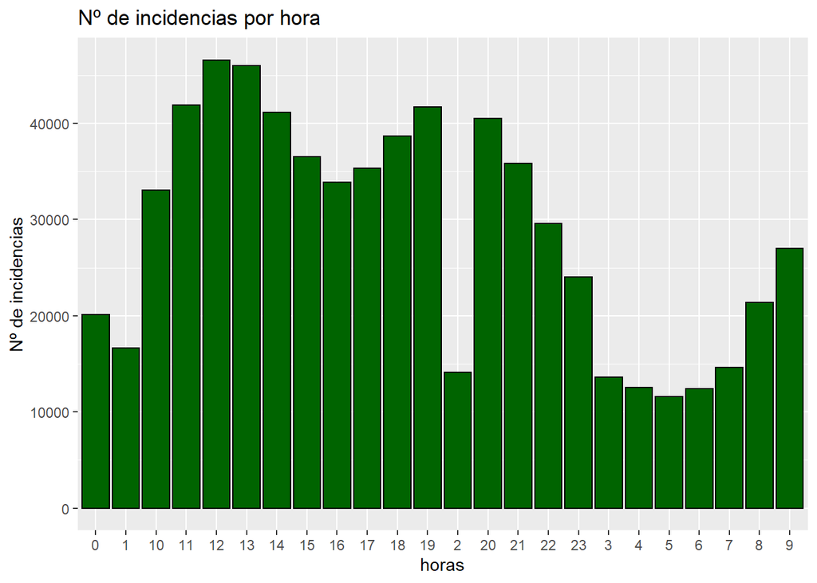

```r
ggplot(samurtotal, aes(x=horas))+geom_histogram(bins = 24,
                                                colour="black", fill="darkgreen",
                                                stat="count")+
                                                labs(title = "Nº de incidencias por hora")+
                                                ylab("Nº de incidencias")
```

12. Muestra gráficamente los avisos recibidos para cada año en función de cada mes ¿Se aprecian las consecuencias de la pandemia del COVID-19 en las activaciones realizadas a lo largo de los años? (Recuerda que el confinamiento en España comenzó en marzo de 2020)

```r
 summary(samurtotal)
```

```
##       Año              Mes             horas           minutos
##  Min.   :2017   MARZO    : 64579   12     : 46586   26     : 11883
##  1st Qu.:2018   ENERO    : 64318   13     : 45980   29     : 11822
##  Median :2019   FEBRERO  : 62039   11     : 41910   28     : 11801
##  Mean   :2019   JUNIO    : 59806   19     : 41708   32     : 11772
##  3rd Qu.:2020   OCTUBRE  : 59575   14     : 41149   27     : 11761
##  Max.   :2022   DICIEMBRE: 58395   20     : 40518   30     : 11732
##                 (Other)  :320071   (Other):430932   (Other):618012
##     segundos      Hora.Intervención     Código                   Distrito
##  07     : 11722   Length:688783      Length:688783      CENTRO       : 99750
##  21     : 11701   Class :character   Class :character   CARABANCHEL  : 47457
##  42     : 11696   Mode  :character   Mode  :character   VALLECAS PTE.: 43102
##  51     : 11695                                         MONCLOA      : 42493
##  53     : 11688                                         LATINA       : 40000
##  29     : 11687                                         TETUAN       : 38084
##  (Other):618594                                         (Other)      :377897
##                        Hospital
##  Gregorio Marañón          : 35286
##  Doce de Octubre           : 32866
##  Concepción (Fund. J. Díaz): 31481
##  La Paz                    : 26443
##  Clínico San Carlos        : 26102
##  (Other)                   : 64810
##  NA's                      :471795
```

```
## Warning: `stat` is deprecated
```

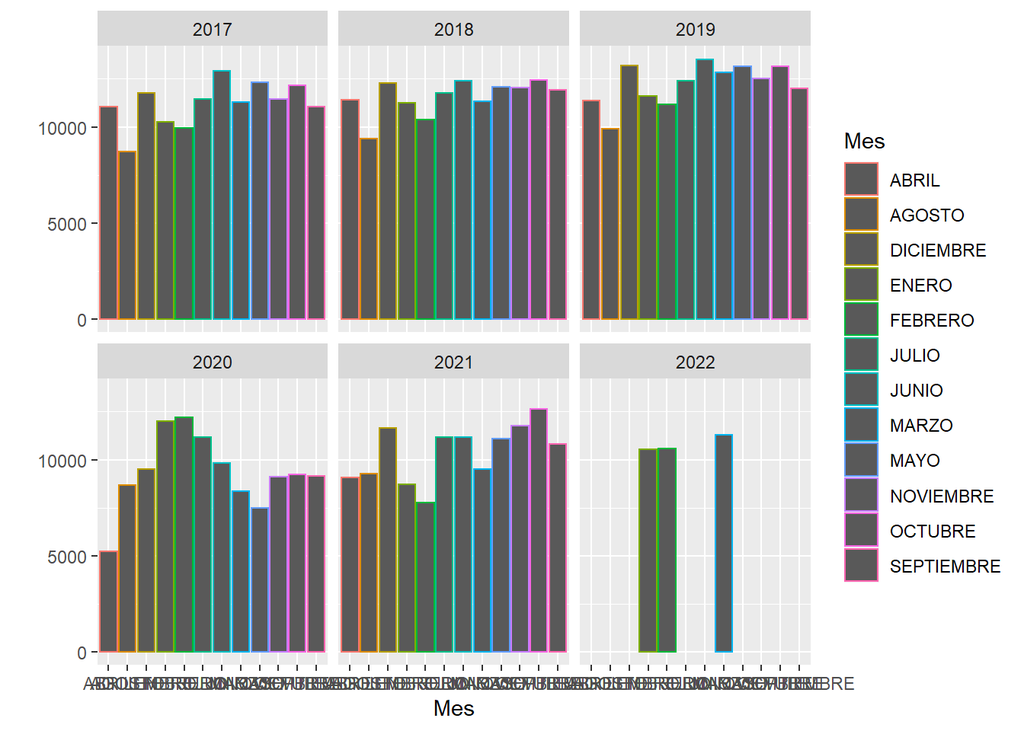

```r
qplot(data = samurtotal, x = Mes,colour = Mes, stat = "count", facets = ~Año )
```

Vemos que antes de la pandemia más o menos el número de avisos era similar en el tiempo. A raiz del Covid esto cambió. Disminuyó, sobre todo en el 2020, año del confinamiento en casa. Del 2022 solo tenemos datos hasta marzo, aunque se puede ver que vuelven a aumentar los casos.